# STAT 413/613: HW on List Columns and COVID19

# 8 Add Population Data to `df_all`

- Use a dplyr join to add the data from `df_pop` to `df_all` to create `df_allp`
- This means there will be two columns with population data:
  - `Population` for US Counties
  - `PopTotal` for the country level

```r
df_all %>%
  left_join(df_pop, by = c("Country_Region" = "Location")) %>%
  select(Population, PopTotal, everything())->df_allp
df_allp
```

```
## # A tibble: 3,225,472 x 16
##    Population PopTotal County Country_State Province_State Country_Region   Lat
##         <dbl>    <dbl> <chr>  <chr>         <chr>          <chr>          <dbl>
##  1          0   38042. NA     Afghanistan   <NA>           Afghanistan     33.9
##  2          0   38042. NA     Afghanistan   <NA>           Afghanistan     33.9
##  3          0   38042. NA     Afghanistan   <NA>           Afghanistan     33.9
##  4          0   38042. NA     Afghanistan   <NA>           Afghanistan     33.9
##  5          0   38042. NA     Afghanistan   <NA>           Afghanistan     33.9
##  6          0   38042. NA     Afghanistan   <NA>           Afghanistan     33.9
##  7          0   38042. NA     Afghanistan   <NA>           Afghanistan     33.9
##  8          0   38042. NA     Afghanistan   <NA>           Afghanistan     33.9
##  9          0   38042. NA     Afghanistan   <NA>           Afghanistan     33.9
## 10          0   38042. NA     Afghanistan   <NA>           Afghanistan     33.9
## # … with 3,225,462 more rows, and 9 more variables: Long <dbl>, Date <date>,
## #   daily_values <dbl>, Continent <chr>, case_type <fct>, LocID <dbl>,
## #   PopDensity <dbl>, rank_p <int>, rank_d <int>
```

# 9 How many Country Regions have Multiple Country States?

- Calculate the number of Country States for each Country Region
- Show in descending order of the number of Country_States by Country_Region.

```r
df_allp %>%
  group_by(Country_Region) %>%
  summarise(num_state = n_distinct(Country_State)) %>%
  arrange(desc(num_state))
```

```
## # A tibble: 192 x 2
##    Country_Region num_state
##    <chr>              <int>
##  1 US                    59
##  2 China                 33
##  3 Canada                16
##  4 France                12
##  5 United Kingdom        12
##  6 Australia              8
##  7 Netherlands            5
##  8 Denmark                3
##  9 Afghanistan            1
## 10 Albania                1
## # … with 182 more rows
```

```r
# 8 Country Regions have Multiple Country States
```

# 10 Analyse Data

1. Create a data frame by with data grouped by `Country_Region`, `Continent` `case_type`, `rank_p` and `rank_d` that summarizes the current totals and the totals as a percentage of total population.
- Be sure to look at how the data is reported so the numbers make sense.

```r
df_allp %>%
  group_by(Country_Region, Continent, case_type, rank_p, rank_d) %>%
  summarise(current_totals = max(daily_values),
            total_percent = current_totals/ (last(PopTotal)*1000)*100) -> df_allp01
df_allp01
```

```
## # A tibble: 386 x 7
## # Groups:   Country_Region, Continent, case_type, rank_p [386]
##    Country_Region Continent case_type rank_p rank_d current_totals total_percent
##    <chr>          <chr>     <fct>      <int>  <int>          <dbl>         <dbl>
##  1 Afghanistan    Asia      confirme…     37    119          57160       0.150
##  2 Afghanistan    Asia      deaths_g…     37    119           2521       0.00663
##  3 Albania        Europe    confirme…    136     79         128393       4.46
##  4 Albania        Europe    deaths_g…    136     79           2317       0.0804
##  5 Algeria        Africa    confirme…     34    165         118516       0.275
##  6 Algeria        Africa    deaths_g…     34    165           3130       0.00727
##  7 Andorra        Europe    confirme…    182     53          12545      16.3
##  8 Andorra        Europe    deaths_g…    182     53            120       0.156
##  9 Angola         Africa    confirme…     45    148          23457       0.0737
## 10 Angola         Africa    deaths_g…     45    148            553       0.00174
## # … with 376 more rows
```

2. What are the 20 Countries with the most confirmed cases and what is the percentage of their total population affected?

```r
df_allp01 %>%
  ungroup() %>%
  filter(case_type == "confirmed_global") %>%
  arrange(desc(current_totals)) %>%
  slice_head(n = 20)->df_allp02
df_allp02
```

```
## # A tibble: 20 x 7
##    Country_Region Continent case_type rank_p rank_d current_totals total_percent
##    <chr>          <chr>     <fct>      <int>  <int>          <dbl>         <dbl>
##  1 US             Americas  confirme…      3    141       31197873         9.48
##  2 India          Asia      confirme…      2     17       13527717         0.990
##  3 Brazil         Americas  confirme…      6    151       13482023         6.39
##  4 France         Europe    confirme…     22     68        5021865         7.71
##  5 Russia         Europe    confirme…      9    176        4589209         3.15
##  6 United Kingdom Europe    confirme…     21     33        4370321         6.47
##  7 Turkey         Asia      confirme…     18     75        3849011         4.61
##  8 Italy          Europe    confirme…     23     49        3769814         6.23
##  9 Spain          Europe    confirme…     30     88        3347512         7.16
## 10 Germany        Europe    confirme…     17     37        3012158         3.61
## 11 Poland         Europe    confirme…     38     65        2574631         6.80
## 12 Colombia       Americas  confirme…     29    134        2536198         5.04
## 13 Argentina      Americas  confirme…     31    168        2532562         5.66
## 14 Mexico         Americas  confirme…     10    115        2280213         1.79
## 15 Iran           Asia      confirme…     19    127        2070141         2.50
## 16 Ukraine        Europe    confirme…     33    104        1905430         4.33
## 17 Peru           Americas  confirme…     43    150        1647694         5.07
## 18 Czechia        Europe    confirme…     85     59        1580189        14.8
## 19 Indonesia      Asia      confirme…      4     57        1566995         0.579
## 20 South Africa   Africa    confirme…     24    130        1558458         2.66
```

3. What are the 20 Countries with the most deaths and what is the percentage of their total population affected?

```r
df_allp01 %>%
  ungroup() %>%
  filter(case_type == "deaths_global") %>%
  arrange(desc(current_totals)) %>%
  slice_head(n = 20)->df_allp03
df_allp03
```

```
## # A tibble: 20 x 7
##    Country_Region Continent case_type rank_p rank_d current_totals total_percent
##    <chr>          <chr>     <fct>      <int>  <int>          <dbl>         <dbl>
##  1 US             Americas  deaths_g…      3    141         562066        0.171
##  2 Brazil         Americas  deaths_g…      6    151         353137        0.167
##  3 Mexico         Americas  deaths_g…     10    115         209338        0.164
##  4 India          Asia      deaths_g…      2     17         170179        0.0125
##  5 United Kingdom Europe    deaths_g…     21     33         127087        0.188
##  6 Italy          Europe    deaths_g…     23     49         114254        0.189
##  7 Russia         Europe    deaths_g…      9    176         101282        0.0694
##  8 France         Europe    deaths_g…     22     68          98118        0.151
##  9 Germany        Europe    deaths_g…     17     37          78500        0.0940
## 10 Spain          Europe    deaths_g…     30     88          76328        0.163
## 11 Colombia       Americas  deaths_g…     29    134          65889        0.131
## 12 Iran           Asia      deaths_g…     19    127          64490        0.0778
## 13 Poland         Europe    deaths_g…     38     65          58421        0.154
## 14 Argentina      Americas  deaths_g…     31    168          57779        0.129
## 15 Peru           Americas  deaths_g…     43    150          54903        0.169
## 16 South Africa   Africa    deaths_g…     24    130          53322        0.0911
## 17 Indonesia      Asia      deaths_g…      4     57          42530        0.0157
## 18 Ukraine        Europe    deaths_g…     33    104          38718        0.0880
## 19 Turkey         Asia      deaths_g…     18     75          33939        0.0407
## 20 Czechia        Europe    deaths_g…     85     59          27808        0.260
```

4. Describe the results based on the totals with the rankings for total population and population density.
- The US has the most confirmed cases and death cases, but the US does not have the most total population in the world and the highest population density in the world. The rank of the total population for India is world number two and the rank of the population density is number 17, which all in front of the US, but India does not have many confirmed and death cases than the US. Most of the countries in the top 20 confirmed cases and death cases countries have a higher total population, but not all of these countries have a high population density.

# 11 Which countries in the top 20 for percentage of population for cases are Not in the top 20 for the absolute number of cases. Which countries in the top 20 for percentage of population for deaths are Not in the top 20 for the absolute number deaths?

- Describe the results based on the per population results with the rankings for total population and population density.

```r
df_allp01 %>%
  ungroup() %>%
  filter(case_type == "confirmed_global") %>%
  arrange(desc(total_percent)) %>%
  slice_head(n = 20)->df_allp04

setdiff(df_allp04, df_allp02)
```

```
## # A tibble: 17 x 7
##    Country_Region Continent case_type rank_p rank_d current_totals total_percent
##    <chr>          <chr>     <fct>      <int>  <int>          <dbl>         <dbl>
##  1 Andorra        Europe    confirme…    182     53          12545         16.3
##  2 Montenegro     Europe    confirme…    162    131          94269         15.0
##  3 San Marino     Europe    confirme…    188     13           4956         14.6
##  4 Slovenia       Europe    confirme…    145     82         226499         10.9
##  5 Luxembourg     Europe    confirme…    163     38          63467         10.3
##  6 Israel         Asia      confirme…    100     21         835933          9.81
##  7 Bahrain        Asia      confirme…    148      3         156462          9.53
##  8 Estonia        Europe    confirme…    151    145         114174          8.61
##  9 Sweden         Europe    confirme…     90    154         857401          8.54
## 10 Panama         Americas  confirme…    125    121         358611          8.44
## 11 Lithuania      Europe    confirme…    138    135         226173          8.20
## 12 Portugal       Europe    confirme…     87     73         827494          8.09
## 13 Belgium        Europe    confirme…     78     22         925476          8.02
## 14 Netherlands    Europe    confirme…     67     16        1350665          7.90
## 15 Hungary        Europe    confirme…     93     77         720164          7.44
## 16 Serbia         Europe    confirme…     98     84         642208          7.32
## 17 Lebanon        Asia      confirme…    106     10         496846          7.25
```

```r
df_allp01 %>%
  ungroup() %>%
  filter(case_type == "deaths_global") %>%
  arrange(desc(total_percent)) %>%
  slice_head(n = 20)->df_allp05

setdiff(df_allp05, df_allp03)
```

```
## # A tibble: 11 x 7
##    Country_Region Continent case_type rank_p rank_d current_totals total_percent
##    <chr>          <chr>     <fct>      <int>  <int>          <dbl>         <dbl>
##  1 San Marino     Europe    deaths_g…    188     13             85         0.251
##  2 Hungary        Europe    deaths_g…     93     77          23417         0.242
##  3 Bosnia and He… Europe    deaths_g…    132    117           7298         0.221
##  4 Montenegro     Europe    deaths_g…    162    131           1373         0.219
##  5 Bulgaria       Europe    deaths_g…    105    118          14418         0.206
##  6 Belgium        Europe    deaths_g…     78     22          23473         0.203
##  7 North Macedon… Europe    deaths_g…    144     98           4228         0.203
##  8 Slovenia       Europe    deaths_g…    145     82           4119         0.198
##  9 Slovakia       Europe    deaths_g…    114     71          10565         0.194
## 10 Portugal       Europe    deaths_g…     87     73          16916         0.165
## 11 Andorra        Europe    deaths_g…    182     53            120         0.156
```

# 12 Create two plots, one for the number of cases and one for the number of deaths over time for the top 20 country/region showing each country and faceting by continent with the same scale for the y axis.

- Use appropriate scales for the axes.
- Create two sets of plots
- Interpret each plot with respect to the total cases/deaths and the path of cases/deaths across different continents.

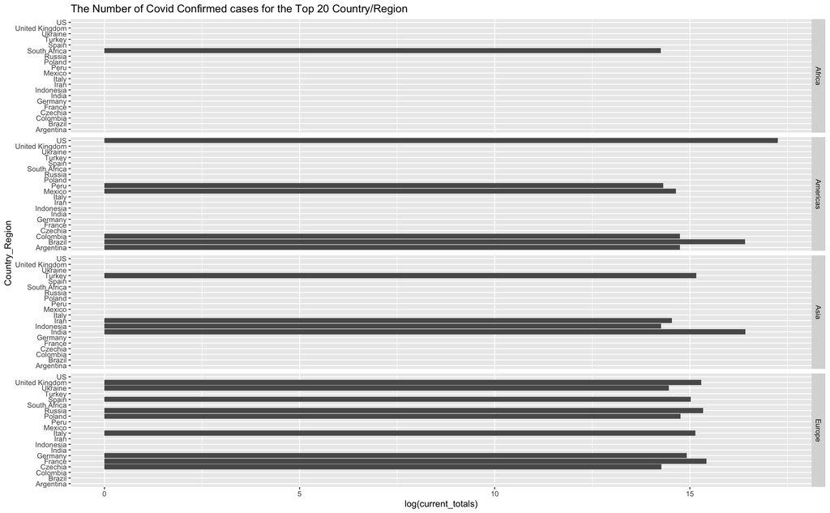

```r
df_allp02 %>%
  ggplot(aes(x = log(current_totals), y = Country_Region)) +
  geom_col() +
  facet_grid(Continent ~ .) +
  ggtitle("The Number of Covid Confirmed cases for the Top 20 Country/Region")
```

- As the plot for the total cases above, we can see that the country which has the most cases is in the US, but based on the continent, Europe has the most countries facing a serious situation since 9 countries out of 20 having the most severe countries are in Europe. Also, based on the continent, Europe is the most severe region, America follows the Euro, and then is Asia. Africa only one country has included in the top 20.

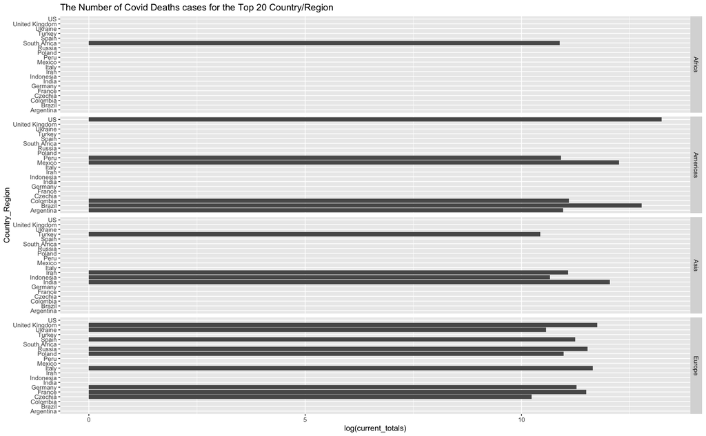

```r
df_allp03 %>%
  ggplot(aes(x = log(current_totals), y = Country_Region)) +
  geom_col() +
  facet_grid(Continent ~ .) +
  ggtitle("The Number of Covid Deaths cases for the Top 20 Country/Region")
```

- We can see that Mexico has a similar number of the confirmed cases with Peru in the plot of the total case. However, Mexico has a higher number of death cases than Peru based on the death cases plot above. Also, we see that Turkey has a higher number of confirmed cases but the number of deaths cases is relatively less. Lastly, the overall trend of the number of death is similar to the number of confirmed cases. The higher confirmed cases the country has, the higher death cases the country has. Europe also has the most countries in the top 20 countries with the most deaths cases in the world

# 13 Analyze US States Deaths **Extra Credit**

1. Create a data frame with the total deaths and deaths per population for those US states with more than 0 deaths and more than 0 population.

```r
df_allp %>%
  group_by(Country_State, case_type) %>%
  summarise(current_totals = max(daily_values),
            total_percent = current_totals/(last(PopTotal)*1000)*100) %>%
  filter(case_type == "deaths_US", current_totals > 0) ->df_allp04
df_allp04
```

```
## # A tibble: 56 x 4
## # Groups:   Country_State [56]
##    Country_State           case_type current_totals total_percent
##    <chr>                   <fct>              <dbl>         <dbl>
##  1 US_Alabama              deaths_US           1487     0.000452
##  2 US_Alaska               deaths_US            165     0.0000501
##  3 US_Arizona              deaths_US           9733     0.00296
##  4 US_Arkansas             deaths_US            634     0.000193
##  5 US_California           deaths_US          23493     0.00714
##  6 US_Colorado             deaths_US            790     0.000240
##  7 US_Connecticut          deaths_US           2355     0.000716
##  8 US_Delaware             deaths_US            788     0.000239
##  9 US_District of Columbia deaths_US           1081     0.000329
## 10 US_Florida              deaths_US           5981     0.00182
## # … with 46 more rows
```

2. Use an appropriate plot to assess for a linear relationship between total deaths and deaths per population using log scales for x and y axes. Interpret the plot.

[figure not shown]

```r
df_allp04 %>%
  ggplot(aes(x = current_totals, y = total_percent))+
  geom_point()+
  scale_x_log10()+
  scale_y_log10()+
  geom_smooth(method = lm, formula = y ~ x, se = FALSE)+
  ggtitle("Total Deaths versus Deaths per Popoulation")+
  xlab("Deaths per Population(log)") +
  ylab("Total Deaths(log)")
```

- As the plot above, the points are spreading as a straight line clearly. It means total deaths and deaths per population have a perfect linear association. Also, the spreading trend of the points is going from the left bottom to the right top which means total deaths and deaths per population are positively related.

3. Run a linear model to test for a linear relationship and interpret the results in terms of p value, adjusted R-squared and a plot of the residuals.

```r
summary(lm(total_percent ~ current_totals, data = df_allp04))
```

```
##
## Call:
## lm(formula = total_percent ~ current_totals, data = df_allp04)
##
## Residuals:
##        Min         1Q     Median         3Q        Max
## -3.175e-18 -9.850e-20 -5.120e-20 -1.650e-20  5.768e-18
##
## Coefficients:
##                 Estimate Std. Error   t value Pr(>|t|)
## (Intercept)    2.318e-19  1.406e-19 1.649e+00    0.105
## current_totals 3.039e-07  3.272e-23 9.289e+15   <2e-16 ***
## ---
## Signif. codes:  0 '***' 0.001 '**' 0.01 '*' 0.05 '.' 0.1 ' ' 1
##
## Residual standard error: 9.035e-19 on 54 degrees of freedom
## Multiple R-squared:      1,  Adjusted R-squared:      1
## F-statistic: 8.628e+31 on 1 and 54 DF,  p-value: < 2.2e-16
```

- Since the p-value is extremely small here (<2.2e-16), the model is significant. Adjusted R-squared equals 1 which is a perfect model. The model almost explains all of the variations in the response variable. However, it barely happened in the real world.